This version of the tutorial 4 script shows how you can use RMarkdown to present your work. Most of it is pretty self explanatory, with the exception of generating tables. In this script I use both the `xtable` and the `kable` command to make the printed tables look nicer in the html file. We also need to use the `results='asis'` command in the r block preamble to make it print the table correctly.

For more info on markdown and what commands are available, be sure to check out John Gruber’s [homepage](http://daringfireball.net/projects/markdown/) and google RMarkdown.

## Preprocessing

### Examining the data

We’ll start by examining the data…

```r
hd <- head(train)
print(xtable(hd),type="html", html.table.attributes = tab.attributes)
```

|  | X | admit | gre | gpa | rank |
| --- | --- | --- | --- | --- | --- |
| 1 | 254 | 1 | 540 | 3.55 | 4 |
| 2 | 90 | 1 | 660 | 4.00 | 2 |
| 3 | 177 | 0 | 520 | 2.62 | 2 |
| 4 | 195 | 1 | 600 | 3.47 | 2 |
| 5 | 124 | 0 | 500 | 2.98 | 3 |
| 6 | 96 | 0 | 660 | 3.33 | 2 |

```r
summ <- summary(train)
print(xtable(summary(train)),type="html", html.table.attributes = tab.attributes)
```

|  | X | admit | gre | gpa | rank |
| --- | --- | --- | --- | --- | --- |
| 1 | Min. : 1.0 | Min. :0.0 | Min. :220.0 | Min. :2.420 | Min. :1.00 |
| 2 | 1st Qu.:100.8 | 1st Qu.:0.0 | 1st Qu.:520.0 | 1st Qu.:3.120 | 1st Qu.:2.00 |
| 3 | Median :205.0 | Median :0.0 | Median :580.0 | Median :3.360 | Median :2.00 |
| 4 | Mean :202.8 | Mean :0.3 | Mean :585.9 | Mean :3.374 | Mean :2.46 |
| 5 | 3rd Qu.:307.2 | 3rd Qu.:1.0 | 3rd Qu.:660.0 | 3rd Qu.:3.650 | 3rd Qu.:3.00 |
| 6 | Max. :399.0 | Max. :1.0 | Max. :800.0 | Max. :4.000 | Max. :4.00 |

### Contingency tables

Contingency tables make sense more for categorical data…

|  | 1 | 2 | 3 | 4 |
| --- | --- | --- | --- | --- |
| 0 | 20 | 83 | 68 | 39 |
| 1 | 23 | 42 | 15 | 10 |

|  | 220 | 300 | 340 | 360 | 380 | 400 | 420 | 440 | 460 | 480 | 500 | 520 | 540 | 560 | 580 | 600 | 620 | 640 | 660 | 680 | 700 | 720 | 740 | 760 | 780 | 800 |
| --- | --- | --- | --- | --- | --- | --- | --- | --- | --- | --- | --- | --- | --- | --- | --- | --- | --- | --- | --- | --- | --- | --- | --- | --- | --- | --- |
| 0 | 1 | 0 | 3 | 4 | 5 | 8 | 4 | 6 | 6 | 8 | 15 | 12 | 15 | 13 | 18 | 11 | 13 | 13 | 10 | 10 | 14 | 4 | 4 | 1 | 0 | 12 |
| 1 | 0 | 1 | 1 | 0 | 0 | 2 | 0 | 1 | 2 | 6 | 1 | 8 | 7 | 5 | 4 | 6 | 9 | 2 | 8 | 6 | 3 | 1 | 2 | 4 | 4 | 7 |

### Convert numerical data to categorical data

Recall, when reading in the data, R tries to infer the type of each column, so columns with integer values are treated as numbers by default. We need them as categories. To convert them, we use the `factor` command.

```r
train$rank <- factor(train$rank)
head(train$rank)
```

```
## [1] 4 2 2 2 3 2
## Levels: 1 2 3 4
```

```r
test$rank <- factor(test$rank)
train$admit <- factor(train$admit)
test$admit <- factor(test$admit)
```

## Analysis

### training the first logistic regression model

```r
model1 <- glm(admit ~ gre + gpa, data = train, family="binomial")
predict1 <- predict(model1, newdata = test, type = "response")
print(xtable(summary(model1)),type="html", html.table.attributes = tab.attributes)
```

|  | Estimate | Std. Error | z value | Pr(>\|z\|) |
| --- | --- | --- | --- | --- |
| (Intercept) | -3.3716 | 1.2228 | -2.76 | 0.0058 |
| gre | 0.0027 | 0.0012 | 2.22 | 0.0266 |
| gpa | 0.2783 | 0.3608 | 0.77 | 0.4404 |

Look at the predict1 values and guess what are the values?

```r
#head(predict1, 50)
print(xtable(data.frame(Predict1 = head(predict1, 25))),type="html", html.table.attributes = 'border="0" style="border-collapse: collapse; text-align: right; width: 25%; "')
```

|  | Predict1 |
| --- | --- |
| 1 | 0.26 |
| 2 | 0.29 |
| 3 | 0.19 |
| 4 | 0.25 |
| 5 | 0.30 |
| 6 | 0.35 |
| 7 | 0.29 |
| 8 | 0.44 |
| 9 | 0.21 |
| 10 | 0.47 |
| 11 | 0.32 |
| 12 | 0.16 |
| 13 | 0.37 |
| 14 | 0.47 |
| 15 | 0.33 |
| 16 | 0.31 |
| 17 | 0.31 |
| 18 | 0.30 |
| 19 | 0.43 |
| 20 | 0.37 |
| 21 | 0.19 |
| 22 | 0.47 |
| 23 | 0.26 |
| 24 | 0.38 |
| 25 | 0.27 |

### Sensitivity/Specifity

In order to change the probabilities to binary decision, we need to find a cutoff. We want a cutoff that gives us the best both sensitivity/specificity.

```r
perf = function(cut, mod, y)
   {
        yhat = (mod$fit>cut)
        w = which(y==1)
        sensitivity = mean( yhat[w] == 1 )
        specificity = mean( yhat[-w] == 0 )
        out = t(as.matrix(c(sensitivity, specificity)))
        colnames(out) = c("sensitivity", "specificity")
        return(out)
     }

perf(0.1,model1,train$admit)
```

```
##      sensitivity specificity
## [1,]           1           0
```

```r
perf(0.5,model1,train$admit)
```

```
##      sensitivity specificity
## [1,]           0           1
```

```r
perf(0.8,model1,train$admit)
```

```
##      sensitivity specificity
## [1,]           0           1
```

Let’s plot the sensitivity and specificity…

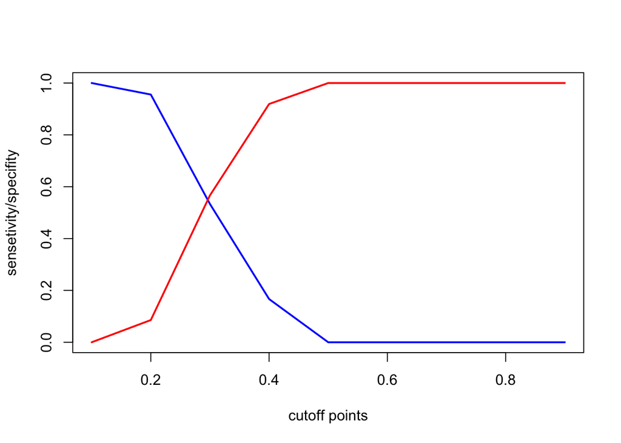

```r
sensetivity=c()
specifity=c()

for(i in seq(0.1, 0.9, by=0.1)){
  sensetivity <- c(sensetivity,perf(i,model1,train$admit)[1])
  specifity <- c(specifity,perf(i,model1,train$admit)[2])
  }

#find the cutoff
plot(seq(0.1, 0.9, by=0.1), sensetivity , type="l", lty=1, col="blue", xlab="cutoff points", ylab="sensetivity/specifity", lwd=2)
lines(seq(0.1, 0.9, by=0.1),specifity, type="l", lty=1, col="red", lwd=2)
```

#### Confusion Matrix

```r
#prediction
predict1 <- ifelse(predict(model1, newdata=test,type="response")>0.3, 1, 0)
confusionmatrix1 <- table(predict1, test$admit)
print(xtable(confusionmatrix1),type="html", html.table.attributes = tab.attributes)
```

|  | 0 | 1 |
| --- | --- | --- |
| 0 | 37 | 10 |
| 1 | 26 | 27 |

#### Accuracy of model over the test data

```r
#accuracy of model over the test data:
sum(diag(confusionmatrix1))/sum(confusionmatrix1)
```

```
## [1] 0.64
```

### Model 2

We now fit a richer model that includes the rank of the school.

```r
model2 <- glm(admit ~ gre + gpa +  rank, data = train, family="binomial")
print(xtable(summary(model2)),type="html", html.table.attributes = tab.attributes)
```

|  | Estimate | Std. Error | z value | Pr(>\|z\|) |
| --- | --- | --- | --- | --- |
| (Intercept) | -2.2490 | 1.3082 | -1.72 | 0.0856 |
| gre | 0.0023 | 0.0012 | 1.87 | 0.0618 |
| gpa | 0.2891 | 0.3741 | 0.77 | 0.4397 |
| rank2 | -0.7935 | 0.3655 | -2.17 | 0.0299 |
| rank3 | -1.6016 | 0.4233 | -3.78 | 0.0002 |
| rank4 | -1.4306 | 0.4739 | -3.02 | 0.0025 |

#### Find the cutoff

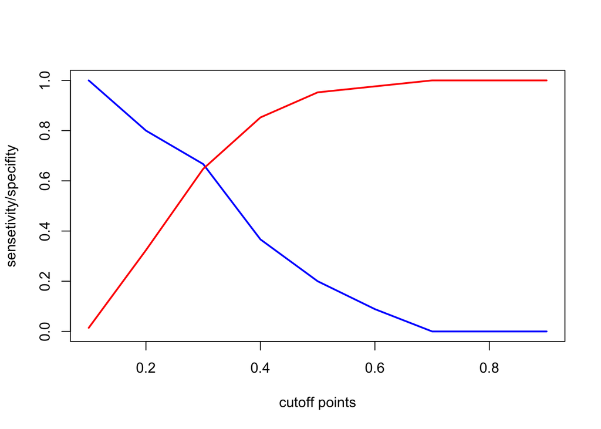

```r
sensetivity=c()
specifity=c()
for(i in seq(0.1, 0.9, by=0.1)){
  sensetivity <- c(sensetivity,perf(i,model2,train$admit)[1])
  specifity <- c(specifity,perf(i,model2,train$admit)[2])
}

plot(seq(0.1, 0.9, by=0.1), sensetivity , type="l", lty=1, col="blue", xlab="cutoff points", ylab="sensetivity/specifity", lwd=2)
lines(seq(0.1, 0.9, by=0.1),specifity, type="l", lty=1, col="red", lwd=2)
```

#### Prediction

```r
predict2 <- ifelse(predict(model2, newdata=test,type="response")>0.3, 1, 0)
confusionmatrix2 <- table(predict2, test$admit)
print(xtable(summary(model2)),type="html", html.table.attributes = tab.attributes)
```

|  | Estimate | Std. Error | z value | Pr(>\|z\|) |
| --- | --- | --- | --- | --- |
| (Intercept) | -2.2490 | 1.3082 | -1.72 | 0.0856 |
| gre | 0.0023 | 0.0012 | 1.87 | 0.0618 |
| gpa | 0.2891 | 0.3741 | 0.77 | 0.4397 |
| rank2 | -0.7935 | 0.3655 | -2.17 | 0.0299 |
| rank3 | -1.6016 | 0.4233 | -3.78 | 0.0002 |
| rank4 | -1.4306 | 0.4739 | -3.02 | 0.0025 |

#### Accuracy of model over the test data

```r
sum(diag(confusionmatrix2))/sum(confusionmatrix2)
```

```
## [1] 0.66
```